# Cremades. Report on Cigarette Consumption in the USA

```r
library(haven)
p081 <- read_sav("p081.sav")
```

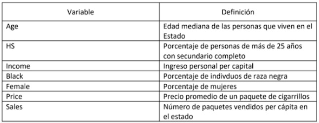

> **It is required to construct a regression equation that relates per-capita cigarette consumption across the state (variable Sales) to various socioeconomic and demographic variables and to determine whether these variables are useful for predicting cigarette consumption.**

## 1. The linear relationship between Sales and the potential predictors is tested, and we check if there are variables that are highly correlated with each other.

```r
lmCigar <- lm(SALES ~ AGE + HS + INCOME + BLACK + FEMALE + PRICE, data = p081)
library(olsrr)
ols_correlations(lmCigar)
```

```
##                Correlations
## -------------------------------------------
## Variable    Zero Order    Partial     Part
## -------------------------------------------
## AGE              0.227      0.207     0.174
## HS               0.067     -0.011    -0.009
## INCOME           0.326      0.269     0.230
## BLACK            0.190      0.110     0.091
## FEMALE           0.146     -0.029    -0.024
## PRICE           -0.301     -0.430    -0.392
## -------------------------------------------
```

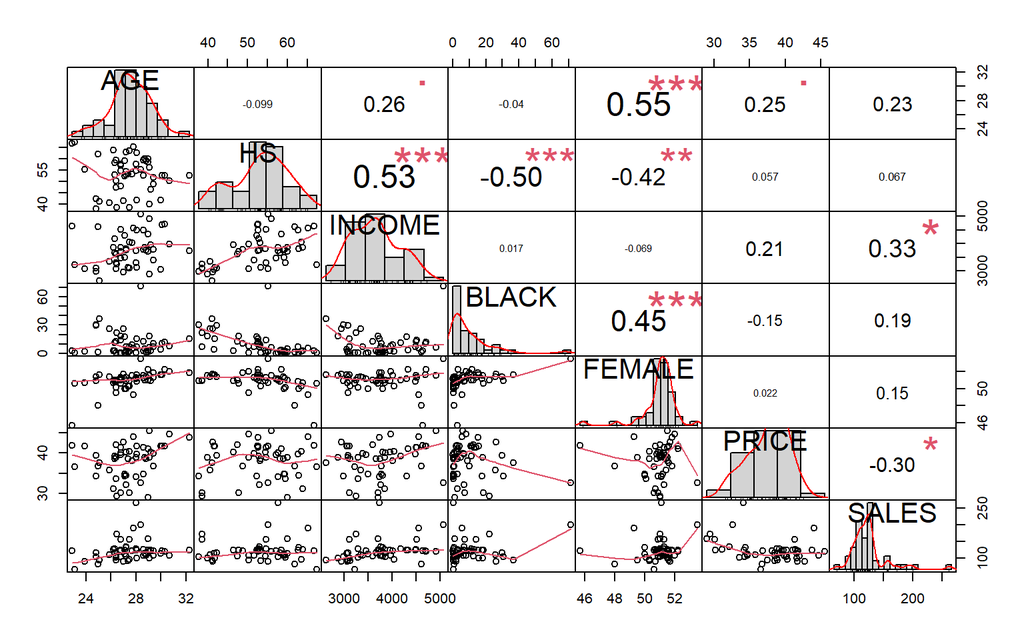

```r
library("PerformanceAnalytics")
chart.Correlation(p081[,2:8], histogram=TRUE)
```

## 2. A multiple linear regression is performed, selecting the best predictors among the available independent variables using an automatic selection method.

```r
ols_step_best_subset(lmCigar, pent = 0.1, prem = 0.15)
```

```
##             Best Subsets Regression
## -----------------------------------------------
## Model Index    Predictors
## -----------------------------------------------
##      1         INCOME
##      2         INCOME PRICE
##      3         AGE INCOME PRICE
##      4         AGE INCOME BLACK PRICE
##      5         AGE INCOME BLACK FEMALE PRICE
##      6         AGE HS INCOME BLACK FEMALE PRICE
## -----------------------------------------------
##
##                                                       Subsets Regression Summary
## ---------------------------------------------------------------------------------------------------------------------------------------
##                        Adj.        Pred
## Model    R-Square    R-Square    R-Square     C(p)        AIC         SBIC        SBC          MSEP         FPE         HSP       APC
## ---------------------------------------------------------------------------------------------------------------------------------------
##   1        0.1063      0.0881      0.0325    10.8981    497.7181    352.4814    503.5136    47835.2430    974.6969    19.5399    0.9666
##   2        0.2503      0.2190       0.153     3.5715    490.7602    346.3234    498.4875    40983.5056    850.4721    17.0899    0.8434
##   3        0.3032      0.2588      0.1888     2.1402    489.0237    345.2967    498.6828    38916.2141    822.1552    16.5731    0.8154
##   4        0.3202      0.2611      0.1807     3.0426    489.7682    346.5663    501.3592    38813.7221    834.5043    16.8888    0.8276
##   5        0.3208      0.2453      0.1299     5.0057    491.7255    348.8506    505.2483    39662.6252    867.5551    17.6417    0.8604
##   6        0.3208      0.2282      0.0772     7.0000    493.7189    351.1638    509.1735    40579.7413    902.7212    18.4598    0.8953
## ---------------------------------------------------------------------------------------------------------------------------------------
## AIC: Akaike Information Criteria
##  SBIC: Sawa's Bayesian Information Criteria
##  SBC: Schwarz Bayesian Criteria
##  MSEP: Estimated error of prediction, assuming multivariate normality
##  FPE: Final Prediction Error
##  HSP: Hocking's Sp
##  APC: Amemiya Prediction Criteria
```

```r
RegreCigar <- ols_regress(SALES ~ AGE + INCOME + PRICE, data = p081)
RegreCigar
```

```
##                          Model Summary
## ----------------------------------------------------------------
## R                        0.551       RMSE                26.506
## R-Squared                0.303       MSE                702.569
## Adj. R-Squared           0.259       Coef. Var           22.717
## Pred R-Squared           0.189       AIC                489.024
## MAE                     16.607       SBC                498.683
## ----------------------------------------------------------------
##  RMSE: Root Mean Square Error
##  MSE: Mean Square Error
##  MAE: Mean Absolute Error
##  AIC: Akaike Information Criteria
##  SBC: Schwarz Bayesian Criteria
##
##                                ANOVA
## --------------------------------------------------------------------
##                  Sum of
##                 Squares        DF    Mean Square      F        Sig.
## --------------------------------------------------------------------
## Regression    15594.426         3       5198.142    6.818     7e-04
## Residual      35831.020        47        762.362
## Total         51425.445        50
## --------------------------------------------------------------------
##
##                                    Parameter Estimates
## ------------------------------------------------------------------------------------------
##       model      Beta    Std. Error    Std. Beta      t        Sig       lower      upper
## ------------------------------------------------------------------------------------------
## (Intercept)    64.248        61.933                  1.037    0.305    -60.345    188.841
##         AGE     4.156         2.199        0.243     1.890    0.065     -0.267      8.579
##      INCOME     0.019         0.007        0.358     2.801    0.007      0.005      0.033
##       PRICE    -3.399         0.989       -0.438    -3.436    0.001     -5.389     -1.409
## ------------------------------------------------------------------------------------------
```

> Since the Age parameter is not significant in the model, we remove it and test a model with two predictors (**INCOME** and **PRICE**).

```r
RegreCigar2 <- ols_regress(SALES ~ INCOME + PRICE, data = p081)
RegreCigar2
```

```
##                          Model Summary
## ----------------------------------------------------------------
## R                        0.500       RMSE                27.495
## R-Squared                0.250       MSE                755.975
## Adj. R-Squared           0.219       Coef. Var           23.318
## Pred R-Squared           0.153       AIC                490.760
## MAE                     16.658       SBC                498.487
## ----------------------------------------------------------------
##  RMSE: Root Mean Square Error
##  MSE: Mean Square Error
##  MAE: Mean Absolute Error
##  AIC: Akaike Information Criteria
##  SBC: Schwarz Bayesian Criteria
##
##                                ANOVA
## --------------------------------------------------------------------
##                  Sum of
##                 Squares        DF    Mean Square      F        Sig.
## --------------------------------------------------------------------
## Regression    12870.711         2       6435.356    8.012    0.0010
## Residual      38554.734        48        803.224
## Total         51425.445        50
## --------------------------------------------------------------------
##
##                                    Parameter Estimates
## ------------------------------------------------------------------------------------------
##       model       Beta    Std. Error    Std. Beta      t        Sig      lower      upper
## ------------------------------------------------------------------------------------------
## (Intercept)    153.338        41.239                  3.718    0.001    70.422    236.255
##      INCOME      0.022         0.007        0.409     3.200    0.002     0.008      0.036
##       PRICE     -3.018         0.994       -0.388    -3.036    0.004    -5.016     -1.019
## ------------------------------------------------------------------------------------------
```

> In the model with two predictors (INCOME and PRICE), all variables are significant, so we decide to work with this model.  
> The linear regression model explains 25% of the variability in the dependent variable (R-squared = 0.250). The model is statistically significant (F = 8.012, p = 0.001), indicating that at least one of the independent variables has a significant effect on the dependent variable.  
> The coefficients show that INCOME has a positive and significant impact on sales (β = 0.022, p = 0.002), while PRICE has a negative and significant effect (β = -3.018, p = 0.004). This implies that an increase in income is associated with higher cigarette sales, while an increase in price reduces sales.

## 3. The collinearity of the predictor variables present in the equation is analyzed.

```r
lmCigar2 <- lm(SALES ~ INCOME + PRICE, data = p081)
ols_vif_tol(lmCigar2)
```

```
##   Variables Tolerance      VIF
## 1    INCOME 0.9539652 1.048256
## 2     PRICE 0.9539652 1.048256
```

> There is no presence of collinearity among the predictor variables.

## 4. A residual analysis of the model is performed to evaluate the fulfillment of the assumptions. For this, residual plots against the predicted values are created.

```r
ols_test_breusch_pagan(lmCigar2)
```

```
##
##  Breusch Pagan Test for Heteroskedasticity
##  -----------------------------------------
##  Ho: the variance is constant
##  Ha: the variance is not constant
##
##               Data
##  ---------------------------------
##  Response : SALES
##  Variables: fitted values of SALES
##
##          Test Summary
##  ------------------------------
##  DF            =    1
##  Chi2          =    8.99775
##  Prob > Chi2   =    0.002703121
```

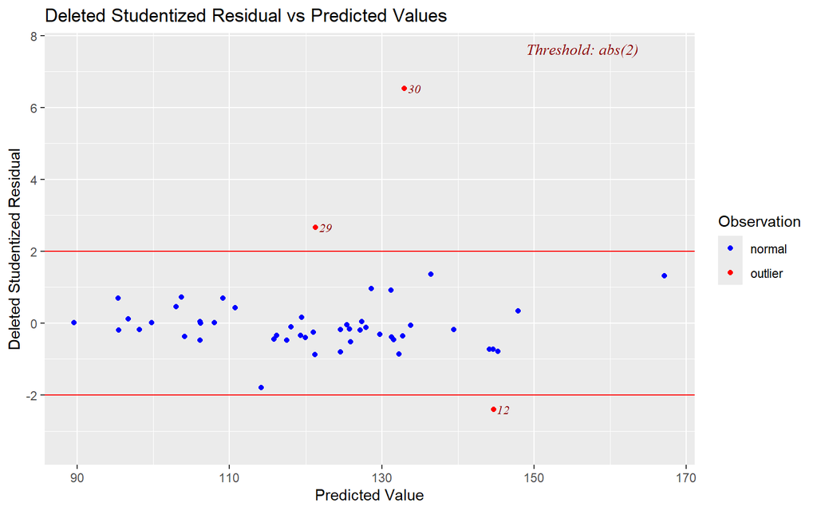

```r
ols_plot_resid_stud_fit(lmCigar2)
```

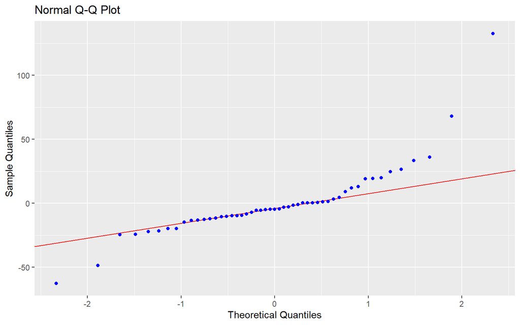

```r
ols_plot_resid_qq(lmCigar2)
```

> The Breusch test rejects the homoscedasticity of variances, and the QQ plot for normality shows some issues on the right tail. On the other hand, the plot of studentized residuals vs predicted values seems to meet the assumptions of normality and homoscedasticity. The initial results mentioned could be explained by the presence of outliers, with observation 30 being very far from the others.

## 5. The presence of outliers and/or influential observations is analyzed. Comment and address the issue as appropriate.

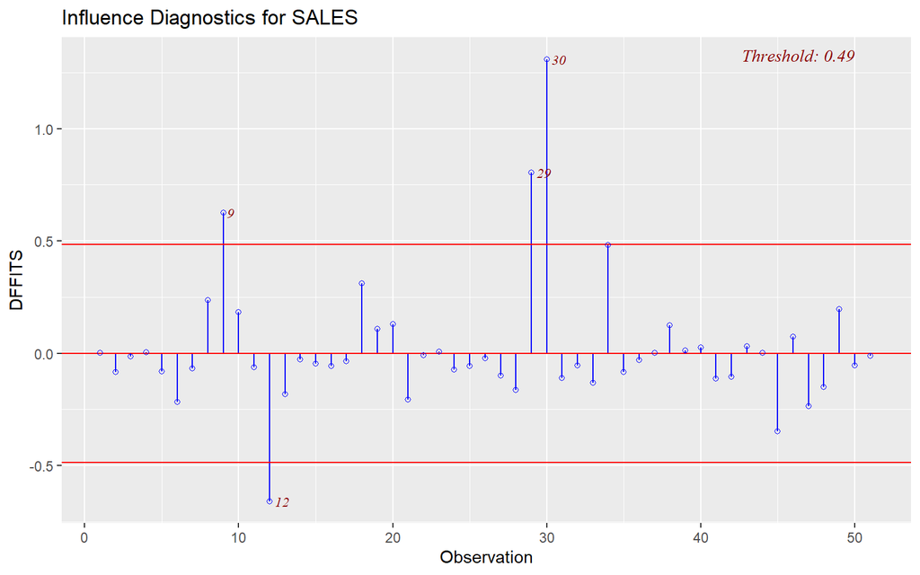

```r
ols_plot_dffits(lmCigar2, print_plot = TRUE)
```

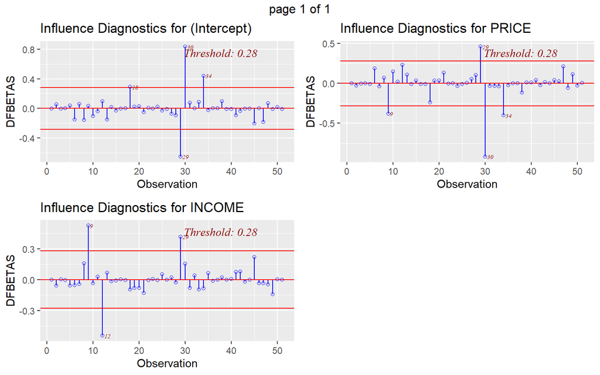

```r
ols_plot_dfbetas(lmCigar2, print_plot = TRUE)
```

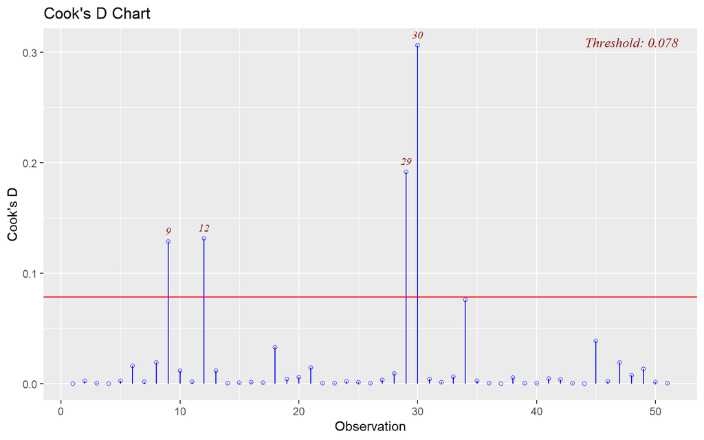

```r
ols_plot_cooksd_chart(lmCigar2, print_plot = TRUE)
```

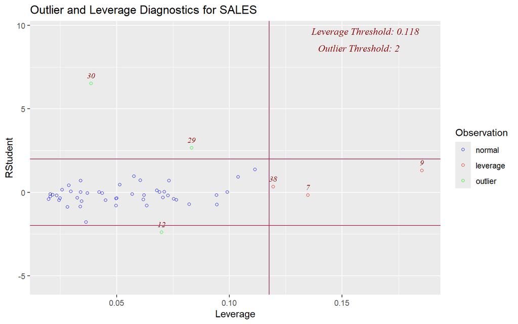

```r
ols_plot_resid_lev(lmCigar2, print_plot = TRUE)
```

> There is evidence of both outliers and leverage. The Cook’s plot identifies observations 30 and 29 as the most distant outliers. In the last plot, observation 9 is seen as an influential observation that could significantly affect the regression line.  
> Since each observation represents a U.S. state, it would not be appropriate to remove these cases, as doing so would prevent the results from being generalized to the entire country. Therefore, we proceed to analyze these particular cases.  
> Observation 30 (New Hampshire) has a much higher number of per-capita cigarette packs sold than the other states. Observation 29 (Nevada) has some of the highest values in both per capita personal income and the average price of cigarette packs. Finally, observation 9 (Washington DC) has one of the highest values in Sales, one of the lowest in Price, and a very high Income compared to the others.

## Final Report

> In conclusion, the model with two predictors, INCOME and PRICE, proves to be statistically significant, with both variables showing a meaningful impact on cigarette sales. The regression model explains 25% of the variability in the dependent variable (R-squared = 0.250) and is highly significant (F = 8.012, p = 0.001), confirming the relevance of the predictors. Specifically, INCOME has a positive influence on sales, while PRICE negatively impacts sales.  
> However, it is important to keep in mind that there is evidence of outliers and leverage in the data. Cook’s plot identifies observations 30 (New Hampshire) and 29 (Nevada) as distant outliers, while observation 9 (Washington DC) is considered influential. Although these observations may have a substantial effect on the regression model, removing them is not advisable, as each observation represents a U.S. state and removing them would compromise the model’s generalizability to the entire country.